# Probability distributions

PCB 6455 / BSC 4933: Biometry | Lecture 12

Dr. Brian Maitner

## Today’s agenda

- Assignment 2
- What a probability distribution is
- The four R functions every distribution has
- The bestiary: which distribution for which kind of data
- What the parameters do

Type and run on a code block: type it into your script and run it. You will need it later. Code without the label is there to watch.

## Assignment 2: Distributions

**Already posted. Due Friday Oct 9, by midnight.**

Two parts:

1. **Twelve kinds of data.** For each: discrete or continuous, then name a distribution, then one sentence on why.
2. **Your own dataset.** At least three numeric variables: histogram, discrete or continuous, mean and median, and an argument for a distribution.

Submit as a `.R` script or the output of a `.Rmd`, same as before.

## You already have most of this

| The assignment asks for | Where you got it |
| --- | --- |
| Discrete or continuous | Tuesday |
| Mean, median, and what the gap means | Tuesday |
| `na.rm = TRUE` on real data | Tuesday |
| Histograms, raw and logged | Lecture 5 |
| Which distribution, and why | **today** |
| Checking a distribution against your data | **today** |

Part 2 needs nothing you have not already done.

## Where we are

**Chapter 3:** the deterministic part. The curve the data follow on average.

**Chapter 4:** the stochastic part. How the data scatter around that curve.

Every model from here on is both: a curve, plus a distribution around it.

## What a distribution is

**Discrete:** a probability for each possible value.

$P(X = 3) = 0.18$. The probabilities add to 1.

**Continuous:** a density, and probability is **area** under it.

$P(X = 3.000...) = 0$. Ask instead for $P(X < 3)$. The total area is 1.

## Every distribution has four functions

| Letter | Means | Normal | Binomial |
| --- | --- | --- | --- |
| `d` | **d**ensity, or probability | `dnorm()` | `dbinom()` |
| `p` | **p**robability of being below | `pnorm()` | `pbinom()` |
| `q` | **q**uantile, the value at a probability | `qnorm()` | `qbinom()` |
| `r` | **r**andom draws | `rnorm()` | `rbinom()` |

The pattern holds for every distribution in section 4.5.

## `d` is for density

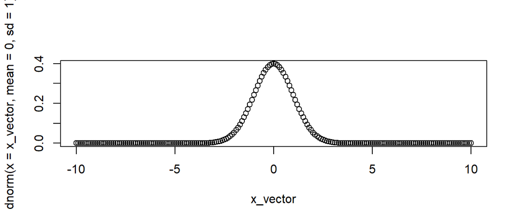

```r
x_vector <- seq(from = -10, to = 10, by = 0.1)

plot(dnorm(x = x_vector, mean = 0, sd = 1) ~ x_vector)
```

## Your turn: what do the parameters do?

```r
x_vector <- seq(from = -10, to = 10, by = 0.1)

# Round 1: change the mean, keep sd the same
plot(dnorm(x = x_vector, mean = 0, sd = 1) ~ x_vector, type = "l")
plot(dnorm(x = x_vector, mean = 3, sd = 1) ~ x_vector, type = "l")

# Round 2: keep the mean, change sd
plot(dnorm(x = x_vector, mean = 0, sd = 2) ~ x_vector, type = "l")
plot(dnorm(x = x_vector, mean = 0, sd = 4) ~ x_vector, type = "l")
```

In your own words: what does `mean` do? What does `sd` do?

## What they do

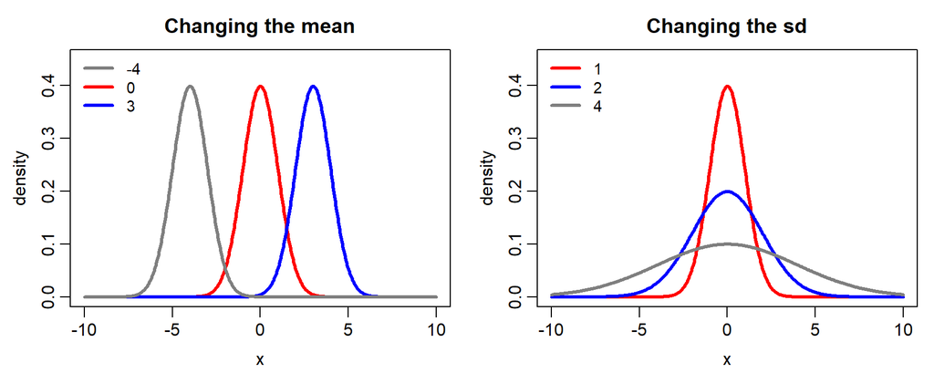

`mean` moves it. `sd` spreads it. The area stays 1.

## `p` is for probability below

```r
pnorm(q = 0, mean = 0, sd = 1)
```

```
[1] 0.5
```

```r
pnorm(q = 1.96, mean = 0, sd = 1)
```

```
[1] 0.9750021
```

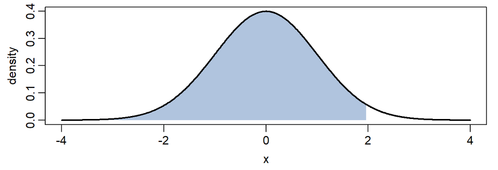

The shaded area is 0.975.

## `q` is for quantile

`q` is `p` backwards. Give it a probability, it gives you the value.

```r
qnorm(p = 0.975, mean = 0, sd = 1)
```

```
[1] 1.959964
```

```r
qnorm(p = 0.5, mean = 10, sd = 2)
```

```
[1] 10
```

## `r` is for random

```r
set.seed(42)
rnorm(n = 5, mean = 0, sd = 1)
```

```
[1]  1.3709584 -0.5646982  0.3631284  0.6328626  0.4042683
```

`set.seed()` makes the randomness repeatable. Run it again, same five numbers.

## Your turn: simulate and compare

```r
draws <- rnorm(n = 100, mean = 10, sd = 2)

hist(draws, freq = FALSE)

curve(dnorm(x, mean = 10, sd = 2), add = TRUE, col = "red", lwd = 2)
```

Now change `n` to 10000. What happens to the match?

## The bestiary

## How do you choose?

1. **Discrete or continuous?** Counts or measurements.
2. **What range?** 0 to 1, 0 to infinity, any number.
3. **What process generated it?** Table 4.1 is organized this way.
4. **Compare the shape** to a histogram of your data.
5. **Look at what others did** with data like yours.

Then **justify it**. More than one answer can be defensible.

## Discrete: binomial

**The story:** a fixed number of tries, each succeeds or fails independently with the same probability.

- `size`: number of tries
- `prob`: probability of success

**Range:** 0 to `size`

`dbinom()`, `rbinom()`

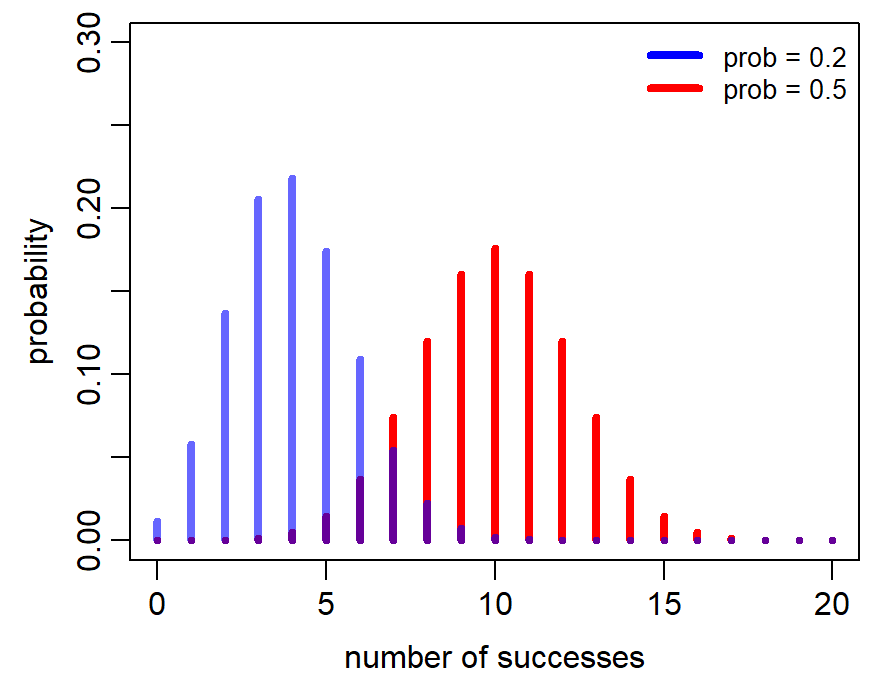

## Your turn: the binomial

```r
k <- seq(from = 0, to = 20, by = 1)

plot(dbinom(x = k, size = 20, prob = 0.5) ~ k, ylim = c(0, 0.3))

# now try these, one at a time
# size = 20, prob = 0.1
# size = 20, prob = 0.9
# size = 5,  prob = 0.5
```

What does `prob` do? What does `size` do?

## Discrete: Poisson

**The story:** counts of things that happen independently at a constant average rate, with no ceiling.

- `lambda`: the mean count

**Range:** 0 to infinity

Mean and variance are **both** `lambda`.

`dpois()`, `rpois()`

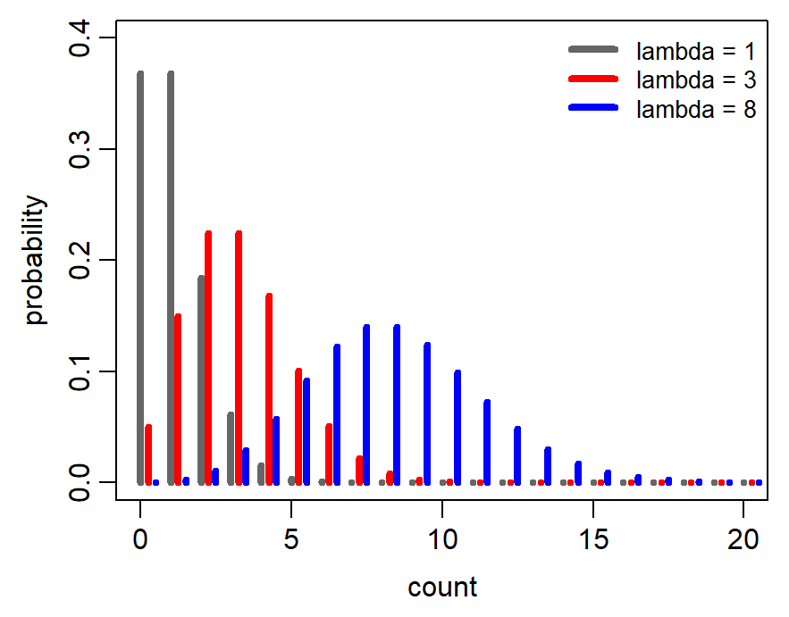

## When the Poisson is not enough

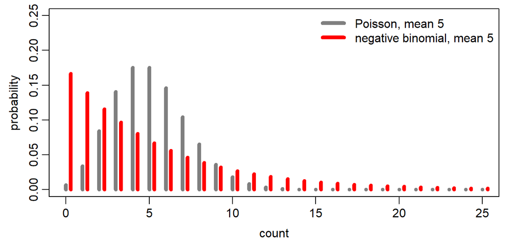

Same mean. The **negative binomial** allows more zeros and more big values: **clumping**.

## Two more discrete

**Geometric**

How many tries until the first success.

- `prob`: success probability

Ages, if the chance of dying each year is constant.

`dgeom()`

**Beta-binomial**

A binomial whose `prob` itself varies between groups.

Infection prevalence across ponds, settlement across tanks.

`dbetabinom()` in `emdbook`

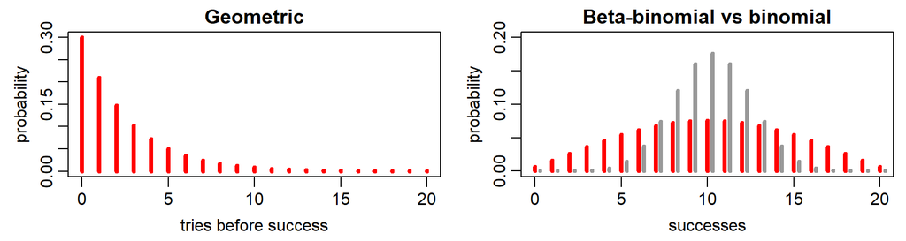

## Continuous: normal and lognormal

**Normal**

Many small effects added together.

Range: any number, including negatives.

`dnorm()`, `rnorm()`

**Lognormal**

Many small effects **multiplied** together.

Range: positive only. Right skewed.

Normal after a log transform.

`dlnorm()`, `rlnorm()`

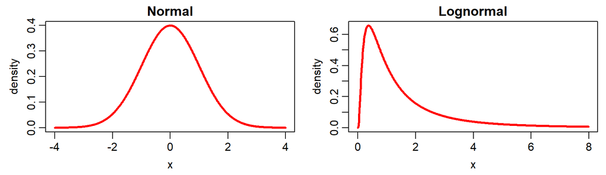

## Continuous: waiting times and proportions

**Exponential and gamma**

Time or distance until something happens.

Exponential: constant hazard. Gamma: the wait for several events.

`dexp()`, `dgamma()`

**Beta**

A proportion, between 0 and 1.

Cover, prevalence, any fraction.

`dbeta()`

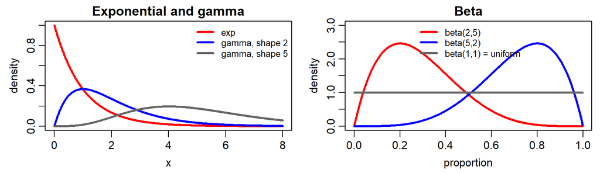

## The whole bestiary, in one picture

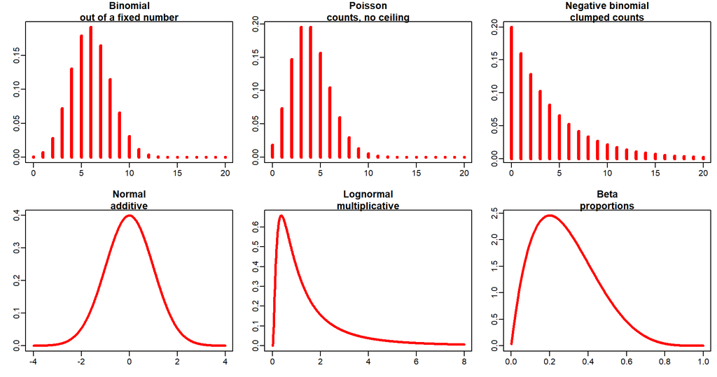

## Your turn: name a distribution

No code. Discrete or continuous first, then a distribution, then why.

1. Number of seeds germinating out of 50 planted
2. Number of beetles on each of 200 trees, where beetles aggregate
3. Time until a radio-tagged bird leaves the study area
4. Proportion of each quadrat covered by moss
5. Body mass of adult fish
6. Number of lightning strikes per square kilometer per year

## Does it match the data?

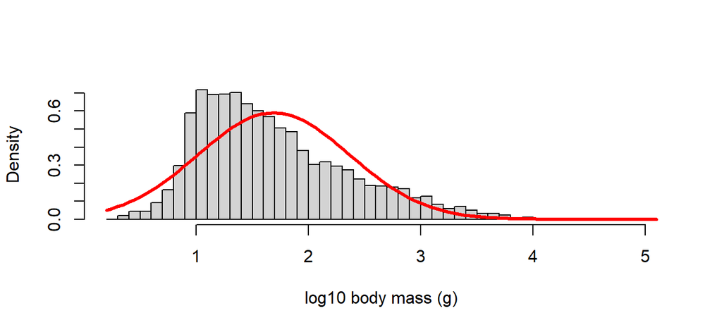

```r
hist(log10(avonet$Mass), freq = FALSE, breaks = 40,
     main = "", xlab = "log10 body mass (g)")

curve(dnorm(x, mean = mean(log10(avonet$Mass)), sd = sd(log10(avonet$Mass))),
      add = TRUE, col = "red", lwd = 3)
```

Roughly **lognormal**: much closer to normal once you take the log, but still right skewed. **Close enough to be useful is the standard.**

## Real data, three times

## Get set up

Run this before the examples. The three of them use these two datasets.

```r
# Breeding Bird Survey counts (about 15 MB, give it a moment)
bbs <- read.csv("https://github.com/bmaitner/biometry_course/raw/refs/heads/main/data/BBS/FL_BBS.csv")

cardinals <- bbs$total_sightings[bbs$Year == 2019 &
                                 bbs$Scientific_Name == "Cardinalis cardinalis"]

length(cardinals)     # should be 71

# the bird trait data from Lecture 5
avonet <- readRDS(url("https://tinyurl.com/avonetbirddata"))
```

## Example 1: counting cardinals

Breeding Bird Survey, Florida, 2019. One count per route, 71 routes.

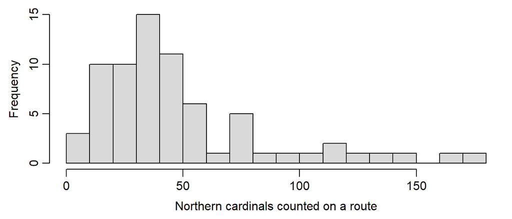

A count with no ceiling. **Poisson?**

## The Poisson makes a testable claim

```r
mean(cardinals)
```

```
[1] 49.4507
```

```r
var(cardinals)
```

```
[1] 1399.994
```

```r
var(cardinals) / mean(cardinals)
```

```
[1] 28.3109
```

A Poisson has **mean = variance**, so that ratio should be about 1.

It is **28**.

## How wrong is the Poisson here?

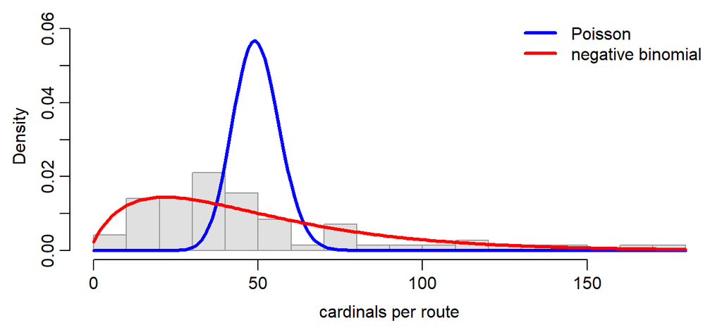

One route counted **175**. The Poisson says that is essentially impossible ($10^{-43}$). The negative binomial says about 1 in 100.

## Matching a negative binomial

The negative binomial has a mean and a clumping parameter. Solve for them from the data:

```r
mu <- mean(cardinals)
size <- mu^2 / (var(cardinals) - mu)

mu
```

```
[1] 49.4507
```

```r
size
```

```
[1] 1.810658
```

Small `size` means heavy clumping. As `size` grows it becomes a Poisson.

## Your turn: a different species

```r
bbs <- read.csv("https://github.com/bmaitner/biometry_course/raw/refs/heads/main/data/BBS/FL_BBS.csv")

counts <- bbs$total_sightings[bbs$Year == 2019 &
                              bbs$Scientific_Name == "Melanerpes carolinus"]

hist(counts)

mean(counts)
var(counts) / mean(counts)
```

Is this one clumped too? Try another species of your own.

## Example 2: killed out of how many

Tadpole predation. Each tank started with a known number, so each result is “killed **out of** Initial”.

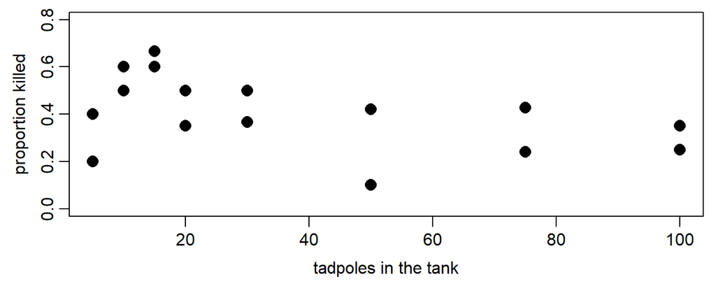

Out of a fixed number, so **binomial**. But the proportion is not constant.

## This is the whole course in one slide

**Chapter 3:** a curve for how the proportion changes with density.

**Chapter 4:** a binomial for the scatter around that curve.

**Chapter 6:** fit both at once. That is what a model is.

## Your turn: how big are bird ranges?

```r
r <- avonet$Range.Size

hist(r, breaks = 50)
mean(r, na.rm = TRUE)
median(r, na.rm = TRUE)

hist(log10(r), breaks = 50)
```

Mean 2,580,000 km². Median 416,000 km². What does that gap tell you? Does the log fix it?

## What the three examples had in common

1. **Plot it.** Shape first.
2. **Use a number, not an impression.** Mean against variance for counts, mean against median for skew.
3. **Overlay the candidate** on the data.
4. **Say how it fails**, and whether that matters.

Nobody looked up a formula.

## A warning: groups hide inside your data

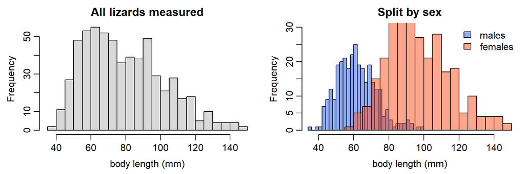

Each sex is **lognormal**. Pooled, they look like nothing in the bestiary.

## The same thing in real data

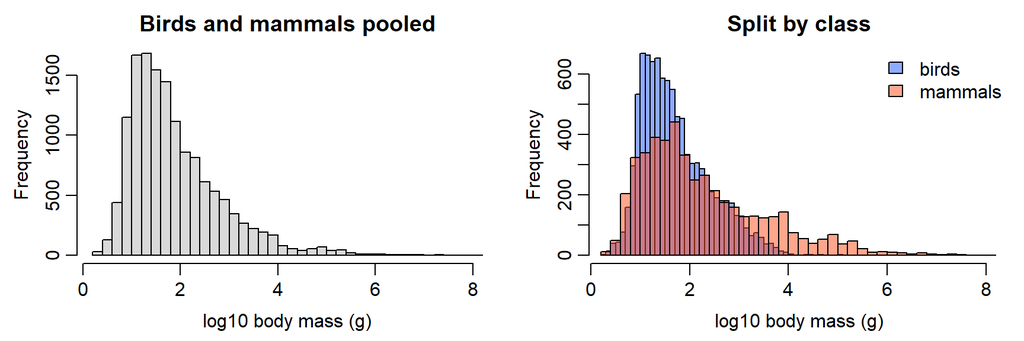

The long right tail is mammals. Birds alone are far tighter.

## What to do about it

1. **Plot by group before naming a distribution.** `boxplot(y ~ group)`, or one histogram per group.
2. **Suspect a mixture** when you see two humps, a shoulder, or a spread far wider than any single distribution would give.
3. **If the groups differ, describe them separately.** A distribution per group beats one bad distribution for everything.
4. **If you cannot measure the group, say so.** That is an honest answer, and it is section 4.6.

Later in the course the group stops being a problem and becomes a **predictor**.

## Your turn: is your variable one thing?

```r
# a grouping column: sex, site, species, year, treatment
boxplot(my_data$your_variable ~ my_data$your_group)

# or one histogram per group
hist(my_data$your_variable[my_data$your_group == "A"])
hist(my_data$your_variable[my_data$your_group == "B"])
```

Does the picture change? If it does, say so in Assignment 2.

## Your turn: start Assignment 2, Part 2

```r
my_data <- read.csv("your_file.csv")

x <- my_data$your_variable

hist(x, freq = FALSE, breaks = 30)

mean(x, na.rm = TRUE)
median(x, na.rm = TRUE)

# if it is positive and right skewed, try the log
hist(log10(x), freq = FALSE, breaks = 30)
```

Then: discrete or continuous? Which distribution, and why?

## Remainder of class

Work on **Assignment 2**.

- Part 1: the twelve items, using Table 4.1 and section 4.5
- Part 2: your own data, the three steps above

Due **Friday Oct 9**, by midnight.

## Before next class

Read Bolker **5.1 to 5.2**

Next time: stochastic simulation, and the midterm explained